# Fundamentals

Compilation of Python code that I've found useful.

```python
import sys
print(f"* Python version:\n{sys.version}\n")
```

```
* Python version:
3.10.6 (tags/v3.10.6:9c7b4bd, Aug  1 2022, 21:53:49) [MSC v.1932 64 bit (AMD64)]
```

## F-strings

```python
x="J"
print(f'Hello, {x}! How are you?')
print(f'Hello, {x.lower()}! How are you?')
print(f'Hello, {x}!','How are you?', sep="\n")
print(f"{2*2}")
print(f'{3.1415:.2}')
```

```
Hello, J! How are you?
Hello, j! How are you?
Hello, J!
How are you?
4
3.1
```

## String Manipulation

```python
word = 'Hello'
print(word[0])    # one char of the word
print(word[0:1])  # one char of the word (same as above)
print(word[0:3])  # the first three char
print(word[:3])   # the first three char
print(word[-3:])  # the last three char
print(word[3:])   # all but the three first char
print(word[:-3])  # all but the three last character
print(word[::-1]) # reversed
```

```
H
H
Hel
Hel
llo
lo
He
olleH
```

```python
word = "Hello World"
print(word.count('o'))           # counting the character “o” in the givenstring
word.split(' ')                  # Split on whitespace | ['Hello', 'World']
word.replace("Hello", "Goodbye") # 'Goodbye World'
print()
print(" ".join(word))           # add a whitespace between every char
print(":".join(word))           # add a : between every char
print(' '.join(reversed(word))) # d l r o W   o l l e H
print()
print(word.title())             # Hello World
print(word.capitalize())        # Hello world
print(word.swapcase())          # hELLO wORLD
print()
print(word.strip())  # removes from both ends
print(word.lstrip()) # removes leading characters (Left-strip)
print(word.rstrip()) # removes trailing characters (Right-strip)
```

```
2

H e l l o   W o r l d
H:e:l:l:o: :W:o:r:l:d
d l r o W   o l l e H

Hello World
Hello world
hELLO wORLD

Hello World
Hello World
Hello World
```

```python
word.isalnum() #check if all char are alphanumeric
word.isalpha() #check if all char in the string are alphabetic
word.isdigit() #test if string contains digits
word.istitle() #test if string contains title words
word.isupper() #test if string contains upper case
word.islower() #test if string contains lower case
word.isspace() #test if string contains spaces
word.endswith('d') #test if string endswith a d
word.startswith('H') #test if string startswith H
```

```
True
```

## Loops

```python
# range() function defaults to 0 as a starting value
for N in range(10):
    print(N, end=' ') # print all on same line
print()

start = 1
end = 11
inc = 2
for N in range(start, end, inc):
    print(N, end=' ') # print all on same line
```

```
0 1 2 3 4 5 6 7 8 9
1 3 5 7 9
```

```python
h = [i for i in range(10)]
print(h)

# Select only even values
h = [i for i in h if (i % 2) == 0]
print(h)
```

```
[0, 1, 2, 3, 4, 5, 6, 7, 8, 9]
[0, 2, 4, 6, 8]
```

```python
# With the continue statement we can stop the current iteration of the loop, and continue with the next:
for n in range(20):
    if n % 2 == 0:
        continue
    print(n, end=' ')
```

```
1 3 5 7 9 11 13 15 17 19
```

```python
# With the break statement we can stop the loop before it has looped through all the items:
# Print Fibonacci sequence for values <= 100
a, b = 0, 1
amax = 100
L = []
while True:
    (a, b) = (b, a + b)
    if a > amax:
        break
    L.append(a)
print(L)
```

```
[1, 1, 2, 3, 5, 8, 13, 21, 34, 55, 89]
```

```python
print(*range(5))  # same as print(0, 1, 2, 3, 4)
```

```
0 1 2 3 4
```

enumerate

```python
n = [{0, 296, 925, 415}, {1}, {2, 1318, 701, 12, 851, 797}, {522, 3, 1115}, {267, 4, 1023}, {5, 1384, 297, 749, 406, 1271, 985, 1404}, {569, 676, 6, 1359}]
for i, n_i in enumerate (n):
    print(i,n_i)
```

```
0 {0, 296, 925, 415}
1 {1}
2 {2, 1318, 797, 12, 851, 701}
3 {522, 3, 1115}
4 {267, 4, 1023}
5 {5, 1384, 297, 749, 406, 1271, 985, 1404}
6 {569, 676, 6, 1359}
```

## Data Types

Dictionaries

```python
d = {'pi_approx': 3.14159265359,
     'e_approx': 2.71828182846,
     'c_approx': '299,792,458 m/s',
     'h_bar_approx': '6.62607004e-34 m^2 kg / s'}
print('d =', d)

d[0] = 0.0
d[1] = 1.0
d[-1] = -1.0
d['minus_one'] = d[-1]

print("\n", len(d), 'key-value pairs:', d)

# Deletion of keys:
d.pop('minus_one')

# Return key-value
print(d['c_approx'])

# List of dictionaries
data = [{'first':'Guido', 'last':'Van Rossum', 'YOB':1956},
        {'first':'Grace', 'last':'Hopper',     'YOB':1906},
        {'first':'Alan',  'last':'Turing',     'YOB':1912}]

sorted(data, key=lambda x: x['YOB'])
'''
[{'first': 'Grace', 'last': 'Hopper', 'YOB': 1906},
 {'first': 'Alan', 'last': 'Turing', 'YOB': 1912},
 {'first': 'Guido', 'last': 'Van Rossum', 'YOB': 1956}]
'''

# Sorting dictionaries
my_dict = {1: 2, 2: 10, "Hello": 1234}
print({key: value for key, value in sorted(my_dict.items(), key=lambda item: item[1])})
# {1: 2, 2: 10, 'Hello': 1234}

# Iterating over dictionaries
D = {k: v for v, k in enumerate('abcdef')}
print(D)


'''
Default Dictionaries
    Python's built-in dictionaries require you to check whether a key exists before updating it.
    A way around that is to use default dict
'''
from collections import defaultdict
# you need to provide a "factory" function that the dictionary can use to create an initial value when the key does not exist.
d = defaultdict(int)
d['existing-key'] = 5 # Create one key-value pair
d['existing-key'] += 1 # Update
d['new-key'] += 1
print('\n', d)
```

```
d = {'pi_approx': 3.14159265359, 'e_approx': 2.71828182846, 'c_approx': '299,792,458 m/s', 'h_bar_approx': '6.62607004e-34 m^2 kg / s'}

 8 key-value pairs: {'pi_approx': 3.14159265359, 'e_approx': 2.71828182846, 'c_approx': '299,792,458 m/s', 'h_bar_approx': '6.62607004e-34 m^2 kg / s', 0: 0.0, 1: 1.0, -1: -1.0, 'minus_one': -1.0}
299,792,458 m/s
{1: 2, 2: 10, 'Hello': 1234}
{'a': 0, 'b': 1, 'c': 2, 'd': 3, 'e': 4, 'f': 5}

 defaultdict(<class 'int'>, {'existing-key': 6, 'new-key': 1})
```

Lists

```python
list_from_string = list('abcdefg')
print(list_from_string)

range_list = list(range(10))
print(range_list)

# Sorting lists, can also specify a sorting function with key=func
range_list.sort(reverse=True)
print(range_list)
range_list.sort(reverse=False)
print(range_list)

y = [1,2,3]
z = y.copy() # .copy() can be used to clone a list to be distinct references.
y.append(4)
print(z)

g = [i for i in range(10)] # 0 .. 9

from random import shuffle
shuffle(g) # permute randomly
print(g)

# Select only even values
h = [i for i in g if (i % 2) == 0]
print(h)
```

```
['a', 'b', 'c', 'd', 'e', 'f', 'g']
[0, 1, 2, 3, 4, 5, 6, 7, 8, 9]
[9, 8, 7, 6, 5, 4, 3, 2, 1, 0]
[0, 1, 2, 3, 4, 5, 6, 7, 8, 9]
[1, 2, 3]
[5, 1, 3, 8, 4, 9, 0, 6, 7, 2]
[8, 4, 0, 6, 2]
```

Sets

```python
# Sets are unordered, unchangeable, unindexed, and duplicates are not allowed.
# Python is free to reorder your values
s = 'quux'
s = set(s)
print(s)

s.add('p')
print(s)

# Removes a random element from a set.
s.pop()
print(s)

s.update({1,2,3})
print(s)

print('x' in s)
print('y' in s)

# Clears a set.
s.clear()
print(s)

A = {1, 2, 3, 4, 5}
B = {3, 4, 5, 6, 7}
print(A, '&', B, '==', A & B) # intersection
print(A, '|', B, '==', A | B) # union
print(A, '-', B, '==', A - B) # difference
print(A, '<', B, '==', A < B) # proper subset (use `<=` for subset, `>` or `>=` for superset, or '==' for equality)
```

```
{'x', 'q', 'u'}
{'x', 'p', 'q', 'u'}
{'p', 'q', 'u'}
{1, 'p', 'q', 2, 3, 'u'}
False
False
set()
{1, 2, 3, 4, 5} & {3, 4, 5, 6, 7} == {3, 4, 5}
{1, 2, 3, 4, 5} | {3, 4, 5, 6, 7} == {1, 2, 3, 4, 5, 6, 7}
{1, 2, 3, 4, 5} - {3, 4, 5, 6, 7} == {1, 2}
{1, 2, 3, 4, 5} < {3, 4, 5, 6, 7} == False
```

Tuples  
Ordered, unchangeable, and allow duplicate values.

```python
t = ("apple", "banana", "cherry")
print(t[0])
print(len(t))
```

```
apple
3
```

## Dates

Format code list - https://www.programiz.com/python-programming/datetime/strptime

```python
from datetime import datetime
date_str = '2020-10-31'
date = datetime.strptime(date_str, '%Y-%m-%d')
print(date)
date_str = date.strftime("%Y-%m-%d")
print(date_str)
```

```
2020-10-31 00:00:00
2020-10-31
```

```python
import datetime
dt_date = datetime.datetime.now()
print("In specified format:", dt_date.strftime("%A, %d %b %Y"))
```

```
In specified format: Sunday, 12 Sep 2021
```

## Random

https://docs.python.org/3/library/random.html

https://www.w3schools.com/python/module_random.asp

```python
import random

# random.randint(start, stop)
print(random.randint(3, 9))
```

```
3
```

## Timeit

```python
import time
t1 = time.time()
print("Hi!")
t2 = time.time()
print(f"The time taken by print statement is {t2 - t1} seconds")
```

```
Hi!
The time taken by print statement is 0.001001596450805664 seconds
```

```python
'''
%timeit - Measure execution time of small code snippets

from random import random
from decimal import Decimal

NUM_TRIALS = 0

print("Native arithmetic:")
A_native = [random() for _ in range(NUM_TRIALS)]
B_native = [random() for _ in range(NUM_TRIALS)]
%timeit [a+b for a, b in zip(A_native, B_native)]

print("\nDecimal package:")
A_decimal = [Decimal(a) for a in A_native]
B_decimal = [Decimal(b) for b in B_native]
%timeit [a+b for a, b in zip(A_decimal, B_decimal)]
'''
```

[output not shown]

## Misc

### Windows Paths

```python
path = r'C:\Users\eric_\Documents\Code\ChromeDriver\chromedriver.exe'
```

### Assertions

```python
def KelvinToFahrenheit(Temperature):
   assert (Temperature >= 0),"Colder than absolute zero!"
   return ((Temperature-273)*1.8)+32

KelvinToFahrenheit(1)
```

```
-457.6
```

```python
'''
One line if statement
    value_when_true if condition else value_when_false

    Note: You cannot use Python if..elif..else block in one line.
          Well you kind of can, but you shouldn't because it is hard to read.
'''
a = 1
b = 'Positive' if a > 0 else 'Negative'
print(b)

# Split string and assign variables to each part
helloworld = 'hello world'
hello, world = helloworld.split(' ')
print(hello,world)
```

```
Positive
hello world
```

# Pip

https://pip.pypa.io/en/stable/user_guide/

pip install --upgrade pip  
pip install SomePackage --upgrade  
pip uninstall SomePackage  
pip install sklearn --upgrade

See outdate packages:  
pip list --outdated

Automatically upgrade all the outdated packages (that were installed using pip):  
`pip install $(pip list --outdated | awk '{ print $1 }') --upgrade`

Another option  
`for i in $(pip list --outdated --format=columns |tail -n +3|cut -d" " -f1); do pip install $i --upgrade; done`

# Regular Expressions

https://docs.python.org/3/howto/regex.html

Build/test expressions - https://regex101.com/

```python
import re
```

```python
##################
# METACHARACTERS #
##################
# [ ] - [abc] will match to any of the characters a, b, c. The same as [a-c]. Matches to metacharacters literally
#       [^5] will match any character except '5'. '^' only works if its the first character. [5^] will match to either 5 or '^'
#       [\s,.] any whitespace, or ',' or '.'
# \ - can be used to escape all metacharacters, \[] would match literally to '[]'
# . - any character except a newline character. alternate mode (re.DOTALL) will match to even newlines
#
#
# \d - any decimal, = [0-9]
# \D - non-digit, = [^0-9]
#
# \s - whitespace, = [ \t\n\r\f\v]
# \S - non-whitespace, = [^ \t\n\r\f\v]
#
# \w - alphanumeric, = [a-zA-Z0-9_]
# \W - non-alphanumeric, = [^a-zA-Z0-9_]
##################
# REPEAT METACHARS #
##################
# * - previous character can be matched zero or more times
#     ca*t will match ct, cat, caaaaat
#
# + - will match one or more times
#     ca+t will match cat, caaaaat
#
# ? - matches zero or one times.
#     home-?brew matches homebrew or home-brew
#
# {m,n} - at least m, at most n repeats. Omitting 'm' will be interpreted as 0. 'n' will be infinity
#         a/{1,3}b will match a/b, a//b, and a///b
##################
# | - 'or' operator, A|B
# ^ - beginning lines
# $ - end of a line
# \A - start of string
# \Z - end of string
# \b - beginning or end of a word(sequence of alphanumeric characters)
# \B - only matches when current position is not a word boundary
```

```python
##################
# COMPILATION FLAGS #
##################
# ACSII, A - makes escapes like \w, \b, \s match only on ASCII characters
# DOTALL, S - make '.' match any character, including newlines
# IGNORECASE, I
# MULTILINE, M - affecting '^', and '$'

pattern_matcher = re.compile ('fox', re.IGNORECASE)
matches = pattern_matcher.search ('The quick brown fox jumps over the lazy dog')

##################
# PATTERN MATCHERS #
##################
# match() - if RE matches at the beginning of the string
# search() - any location where the RE matches
# findall() - all substrings where RE matches, returns list
# finditer() - all substrings where RE matches, returns iterator

print (matches)
print (matches.group ()) # group() - return the string matched by RE
print (matches.start ()) # start() - return the starting position of the match
print (matches.end ())  # end() - return the ending position of the match
print (matches.span ()) # span() - return a tuple containing the (start,end) positions
```

```
<re.Match object; span=(16, 19), match='fox'>
fox
16
19
(16, 19)
```

```python
##################
# LOOKAHEAD ASSERTIONS #
##################
# (?=...) - positive lookahead
# (?!...) - negative lookahead
```

```python
# (?P<name>...) - named group. Grab the names with match.group(). match.groupdict() returns a dict of groups
#                 example: (?P<first>[a-zA-Z]+)
```

```python
# Make the above more readable with a re.VERBOSE pattern
# Named groups <name>
re_names3 = re.compile ('''^
                           (?P<first>[a-zA-Z]+)
                           \s
                           (?P<middle>[a-zA-Z]+\s)?
                           \s*
                           (?P<last>[a-zA-Z]+)
                           $
                        ''',
                        re.VERBOSE)
print (re_names3.match ('Rich Vuduc').group ('first'))
print (re_names3.match ('Rich S Vuduc').group ('middle'))
print (re_names3.match ('Rich Salamander Vuduc').group ('last'))
```

```
Rich
S
Vuduc
```

```python
s = '(404) 555-1212'
pattern = '''
        ^\s*               # Leading spaces
        (?P<areacode>
           \d{3}-?         # "xxx" or "xxx-"
           | \(\d{3}\)\s*  # OR "(xxx) "
        )
        (?P<prefix>\d{3})  # xxx
        -?                 # Dash (optional)
        (?P<suffix>\d{4})  # xxxx
        \s*$               # Trailing spaces
    '''
matcher = re.compile(pattern, re.VERBOSE)
matches = matcher.match(s)
if matches is None:
    raise ValueError("'{}' is not in the right format.".format (s))
areacode = re.search('\d{3}', matches.group ('areacode')).group()
prefix = matches.group ('prefix')
suffix = matches.group ('suffix')
(areacode, prefix, suffix)
```

```
('404', '555', '1212')
```

# Numpy

https://numpy.org/

```python
import numpy as np
from numpy.random import default_rng
print(np.__version__)
```

```
1.20.2
```

## Array creation

```python
print(' np.zeros((3, 4))')
print(np.zeros((3, 4))) # creates an array from available memory space, and then fills it with zeros for your chosen dtype.

print('\n np.ones((3, 4))')
print(np.ones((3, 4)))

print('\n np.eye(3)')
print(np.eye(3))

print('\n np.diag([1, 2, 3])')
print(np.diag([1, 2, 3]))

print('\n np.empty((3, 4))')
print(np.empty((3, 4))) #  creates an array from available memory space, leaving whatever values happened to be hanging around in memory as the values.
```

```
 np.zeros((3, 4))
[[0. 0. 0. 0.]
 [0. 0. 0. 0.]
 [0. 0. 0. 0.]]

 np.ones((3, 4))
[[1. 1. 1. 1.]
 [1. 1. 1. 1.]
 [1. 1. 1. 1.]]

 np.eye(3)
[[1. 0. 0.]
 [0. 1. 0.]
 [0. 0. 1.]]

 np.diag([1, 2, 3])
[[1 0 0]
 [0 2 0]
 [0 0 3]]

 np.empty((3, 4))
[[1. 1. 1. 1.]
 [1. 1. 1. 1.]
 [1. 1. 1. 1.]]
```

```python
a = np.array([1,2,3,4])
print(a,"\n")

a = np.arange(9).reshape(3, 3)
print(a,"\n")

# Create a two-dimensional array of size 3 rows x 4 columns:
b = np.array([[0, 1, 2, 3],
              [4, 5, 6, 7],
              [8, 9, 10, 11]])
print(b,"\n")
```

```
[1 2 3 4]

[[0 1 2]
 [3 4 5]
 [6 7 8]]

[[ 0  1  2  3]
 [ 4  5  6  7]
 [ 8  9 10 11]]
```

### Random

```python
rng = default_rng(12345)
#vals = rng.standard_normal(10)
np.random.seed(3)
x = np.random.randint(0, 20, 15) # 15 random ints in [0, 20)
print(x)

# Pull out an arbitrary subset of elements
inds = np.array([3, 7, 8, 12])
print(x[inds])
```

```
[10  3  8  0 19 10 11  9 10  6  0 12  7 14 17]
[ 0  9 10  7]
```

```python
rand_A = np.random.randint(-10, 10, size=(4, 3)) # return random integers from -10 (inclusive) to 10 (exclusive)
print(rand_A)
```

```
[[-8 -8 -9]
 [ 9 -5 -2]
 [ 4 -9  0]
 [-3  1 -9]]
```

```python
c = rng.integers(-10, 10, size=(4, 3)) # return random integers from -10 (inclusive) to 10 (exclusive)
print(c,"\n")

d = rng.integers(-10, 10, size=c.shape) # return random integers from -10 (inclusive) to 10 (exclusive)
print(d,"\n")
```

```
[[ 3 -6  5]
 [-4 -6  5]
 [ 2  3  9]
 [-3  6 -4]]

[[ 1  1 -6]
 [-7 -6  3]
 [ 2  8  4]
 [-6  8  8]]
```

```python
mins = [0, 0] # Two columns, minumum value
maxs = [[5], [5], [5]] # Three columns, max values
print(np.random.randint(mins, maxs, dtype=np.uint8))

mins = [5, 5] # Two columns, minumum value
maxs = [[10], [10], [10]] # Three columns, max values
print("\n",np.random.randint(mins, maxs, dtype=np.uint8))
```

```
[[3 1]
 [1 2]
 [0 0]]

 [[9 9]
 [6 6]
 [8 7]]
```

### Concatenate

https://numpy.org/doc/stable/reference/generated/numpy.concatenate.html

```python
a = np.array([[1, 2], [3, 4]])
b = np.array([[5, 6]])
new_a = np.concatenate((a, b), axis=0)
print(new_a)
```

```
[[1 2]
 [3 4]
 [5 6]]
```

### Append

https://numpy.org/doc/stable/reference/generated/numpy.append.html

```python
'''Parameters:
 arr - Values are appended to a copy of this array.
 values - These values are appended to a copy of arr.
 axis (opt)
'''

a = np.append(a, [7, 8, 9])
a
```

```
array([1, 2, 3, 4, 7, 8, 9])
```

### Astype

```python
a = a.astype(float)
a
```

```
array([1., 2., 3., 4., 7., 8., 9.])
```

## Boolean Masks

```python
print(x)
mask_mult_3 = (x > 0) & (x % 3 == 0)
print(mask_mult_3)
```

```
[10  3  8  0 19 10 11  9 10  6  0 12  7 14 17]
[False  True False False False False False  True False  True False  True
 False False False]
```

```python
print(x[mask_mult_3])       # True values
print(np.where(mask_mult_3)) # True indeces
```

```
[ 3  9  6 12]
(array([ 1,  7,  9, 11], dtype=int64),)
```

## Broadcasting

https://numpy.org/doc/stable/reference/ufuncs.html#broadcasting

Combine operations on numpy arrays that have different shapes but are *compatible*. Technically, `A` and `3` have different shapes: the former is a $4 \times 3$ matrix, while the latter is a scalar ($1 \times 1$). However, they are compatible because Numpy knows how to *extend*---or **broadcast**---the value 3 into an equivalent matrix object of the same shape in order to combine them.

```python
print(c,"\n\n",c+3)
c_row_means = np.mean(c, axis=0)
print("\n", c_row_means)
c_col_means = np.mean(c, axis=1)
print("\n", c_col_means)

print(c.shape, c_row_means.shape)
print(c.shape, c_col_means.shape)
print()
c_col_means2 = np.reshape(c_col_means, (len(c_col_means), 1))
print(c_col_means2, "=>", c_col_means2.shape)
print()
print("A - A_col_means2\n\n", c, "\n-", c_col_means2)
print("\n=>\n", c - c_col_means2)
```

```
[[ 3 -6  5]
 [-4 -6  5]
 [ 2  3  9]
 [-3  6 -4]]

 [[ 6 -3  8]
 [-1 -3  8]
 [ 5  6 12]
 [ 0  9 -1]]

 [-0.5  -0.75  3.75]

 [ 0.66666667 -1.66666667  4.66666667 -0.33333333]
(4, 3) (3,)
(4, 3) (4,)

[[ 0.66666667]
 [-1.66666667]
 [ 4.66666667]
 [-0.33333333]] => (4, 1)

A - A_col_means2

 [[ 3 -6  5]
 [-4 -6  5]
 [ 2  3  9]
 [-3  6 -4]]
- [[ 0.66666667]
 [-1.66666667]
 [ 4.66666667]
 [-0.33333333]]

=>
 [[ 2.33333333 -6.66666667  4.33333333]
 [-2.33333333 -4.33333333  6.66666667]
 [-2.66666667 -1.66666667  4.33333333]
 [-2.66666667  6.33333333 -3.66666667]]
```

## Indexing / Slicing

when you slice a Numpy array, you are actually creating a view into that array. That means modifications through the view will modify the original array.

```python
A = np.array ([[1, 2, 3],
               [4, 5, 6],
               [7, 8, 9]
              ], dtype=float)

print ("A[:, :] ==\n", A)
print ("\nA[0, :] ==\n", A[0, :])
print ("\nA[:, 0:1] ==\n", A[:, 0:1])
print ("\nA[:, 2:3] == \n", A[:, 2:3])

print ("\nAdd columns 0 and 2?")
a0 = A[:, 0:1]
a1 = A[:, 2:3]
print (a0 + a1)
```

```
A[:, :] ==
 [[1. 2. 3.]
 [4. 5. 6.]
 [7. 8. 9.]]

A[0, :] ==
 [1. 2. 3.]

A[:, 0:1] ==
 [[1.]
 [4.]
 [7.]]

A[:, 2:3] ==
 [[3.]
 [6.]
 [9.]]

Add columns 0 and 2?
[[ 4.]
 [10.]
 [16.]]
```

## Functions

```python
npFunc = np.array([[0, 1, 2, 3],
                  [4, 5, 6, 7],
                  [8, 9, 10, 11]])
print(npFunc.ndim) # Number of array dimensions
print(npFunc.shape) # Rows x Columns
print(len(npFunc)) # Number of rows

# Math is straightforward sometimes
npFunc = npFunc*10
print("\n",npFunc)
npFunc = npFunc-1
print(npFunc,"\n",)

#print(np.mean(c.T, axis=1))
# aggregate all values
print("np.max =", np.max(npFunc))
print("np.min =",np.min(npFunc))
print("np.sum =",np.sum(npFunc))
print("np.mean =",np.mean(npFunc))
print("np.nanmean =",np.nanmean(npFunc)) # ignore NaN values
print("np.std =",np.std(npFunc))
print()
# aggregate along a dimension
print("Max in each column:", np.amax(npFunc, axis=0)) # i.e., aggregate along axis 0, the rows, producing column maxes
print("Max in each row:", np.amax(npFunc, axis=1)) # i.e., aggregate along axis 1, the columns, producing row maxes
```

```
2
(3, 4)
3

 [[  0  10  20  30]
 [ 40  50  60  70]
 [ 80  90 100 110]]
[[ -1   9  19  29]
 [ 39  49  59  69]
 [ 79  89  99 109]]

np.max = 109
np.min = -1
np.sum = 648
np.mean = 54.0
np.nanmean = 54.0
np.std = 34.52052529534663

Max in each column: [ 79  89  99 109]
Max in each row: [ 29  69 109]
```

### Universal functions

Universal functions apply a given function *elementwise* to one or more Numpy objects.

[np.frompyfunc()](https://docs.scipy.org/doc/numpy/reference/generated/numpy.frompyfunc.html)

```python
print(-npFunc,"\n")
print("np.abs(c)","\n",npFunc, "\n==>\n", np.abs(npFunc),"\n")

print("maximum(c,d)\n",np.maximum(npFunc,npFunc),"\n")

# Create universal functions
def f(x):
    from math import exp
    return exp(-(x**2))
f_np = np.frompyfunc(f,1,1)
print(f_np(npFunc))
```

```
[[   1   -9  -19  -29]
 [ -39  -49  -59  -69]
 [ -79  -89  -99 -109]]

np.abs(c)
 [[ -1   9  19  29]
 [ 39  49  59  69]
 [ 79  89  99 109]]
==>
 [[  1   9  19  29]
 [ 39  49  59  69]
 [ 79  89  99 109]]

maximum(c,d)
 [[ -1   9  19  29]
 [ 39  49  59  69]
 [ 79  89  99 109]]

[[0.36787944117144233 6.639677199580735e-36 1.6584104776811452e-157 0.0]
 [0.0 0.0 0.0 0.0]
 [0.0 0.0 0.0 0.0]]
```

## Matrix Multiplication

You can only multiply two matrices if the number of columns in the first matrix equals the number of rows in the second matrix.

```python
mm = [0, 1, 2, 3]
mm = np.array(mm)
MM = [[ 0,  1,  2,  3,  4,  5],
     [ 6,  7,  8,  9, 10, 11],
     [12, 13, 14, 15, 16, 17],
     [18, 19, 20, 21, 22, 23]]
MM = np.array(MM)
print(mm.shape, MM.shape)
print("\n",mm)
mm = np.expand_dims(mm, axis=-1) # Add an extra dimension in the last axis.
print(mm,"\n")
print(mm.shape, MM.shape)
print(mm*MM)
#print(mm.dot(MM)) # shapes (4,1) and (4,6) not aligned: 1 (dim 1) != 4 (dim 0)
```

```
(4,) (4, 6)

 [0 1 2 3]
[[0]
 [1]
 [2]
 [3]]

(4, 1) (4, 6)
[[ 0  0  0  0  0  0]
 [ 6  7  8  9 10 11]
 [24 26 28 30 32 34]
 [54 57 60 63 66 69]]
```

# Pandas

https://pandas.pydata.org/pandas-docs/stable/user_guide/options.html#available-options

```python
import pandas as pd
from io import StringIO
from IPython.display import display
import sys

print(f"* pandas version: {pd.__version__}")
```

```
* pandas version: 1.2.4
```

Settings

```python
print("Display Rows:",pd.get_option("display.max_rows"))
print("Display Columns:",pd.get_option("display.max_columns"))
print("Display Precision:",pd.get_option("precision"))
#pd.set_option("display.max_rows", 5)
#pd.set_option("display.max_columns", 5)
#pd.set_option("precision", 5) # display precision in terms of decimal places
#pd.set_option("expand_frame_repr", True)
#pd.set_option("chop_threshold", 0) # what level pandas rounds to zero when it displays a Series
```

```
Display Rows: 60
Display Columns: 20
Display Precision: 6
```

## DataFrame Creation

```python
df = pd.DataFrame() # empty

covid = pd.DataFrame({'Timestamp': ['2020-03-12', '2020-03-17', '2020-03-11', '2020-03-15', '2020-03-18', '2020-03-16', '2020-03-13','2020-03-14'],
              'ST': ['GA', 'GA', 'GA','GA','GA', 'GA', 'GA','GA'],
              'Confirmed': [42,121,17,66,146,99,31,31]})
```

Read_table / read_csv / read_... https://pandas.pydata.org/pandas-docs/version/0.18.1/generated/pandas.read_table.html

```python
#df = pd.read_html(url)
#df = pd.read_json(path)
#df = pd.read_sql(query,connection)
#df = pd.read_excel('name.xlsx')
#df = pd.read_clipboard # eg from Excel copy

faithful = pd.read_table("http://www.stat.cmu.edu/~larry/all-of-statistics/=data/faithful.dat",
                         skiprows=20, delim_whitespace=True)

A_csv = """country,year,cases
Afghanistan,1999,745
Brazil,1999,37737
China,1999,212258
Afghanistan,2000,2666
Brazil,2000,80488
China,2000,213766"""
with StringIO(A_csv) as fp:
    A = pd.read_csv(fp)
B_csv = """country,year,population
Afghanistan,1999,19987071
Brazil,1999,172006362
China,1999,1272915272
Afghanistan,2000,20595360
Brazil,2000,174504898
China,2000,1280428583"""
with StringIO(B_csv) as fp:
    B = pd.read_csv(fp)
C = A.merge(B, on=['country', 'year'])
with StringIO("""x,y,z
bug,1,d
rug,2,d
lug,3,d
mug,4,d""") as fp:
    D = pd.read_csv(fp)
with StringIO("""x,y,w
hug,-1,e
smug,-2,e
rug,-3,e
tug,-4,e
bug,1,e""") as fp:
    E = pd.read_csv(fp)
```

Random Data

```python
df = (pd.DataFrame(np.random.rand(10, 6),
                  columns = list('ABCDEF')) - 0.5).cumsum()
df['Group'] = [np.random.choice(list('abcd')) for _ in range(len(df))]
df['Date'] = pd.date_range('1/1/2017', periods=len(df), freq='D')
display(df)
```

|  | A | B | C | D | E | F | Group | Date |
| --- | --- | --- | --- | --- | --- | --- | --- | --- |
| 0 | 0.393065 | 0.218422 | -0.479385 | -0.357283 | -0.174694 | 0.308929 | a | 2017-01-01 |
| 1 | 0.292056 | 0.143124 | -0.565667 | -0.070144 | 0.038872 | -0.167953 | a | 2017-01-02 |
| 2 | 0.107823 | 0.205894 | -0.317509 | 0.039479 | -0.257774 | -0.014322 | a | 2017-01-03 |
| 3 | 0.270510 | 0.576966 | -0.006282 | -0.086396 | -0.682573 | 0.246256 | a | 2017-01-04 |
| 4 | -0.165721 | 0.918007 | 0.186352 | -0.140495 | -0.820233 | 0.262351 | a | 2017-01-05 |
| 5 | -0.208388 | 1.226369 | 0.002637 | 0.203292 | -0.830942 | 0.302470 | d | 2017-01-06 |
| 6 | 0.117740 | 1.247974 | -0.354764 | 0.005555 | -0.523919 | 0.121965 | b | 2017-01-07 |
| 7 | -0.361035 | 1.230419 | -0.828738 | 0.011129 | -0.105889 | -0.171069 | d | 2017-01-08 |
| 8 | 0.064698 | 1.007742 | -1.152676 | 0.501431 | 0.086762 | 0.081072 | a | 2017-01-09 |
| 9 | -0.319085 | 0.593743 | -0.987051 | 0.331002 | -0.051588 | 0.107183 | a | 2017-01-10 |

## Append / Drop / Filter / Impute

Append / Add Columns  
https://pandas.pydata.org/pandas-docs/stable/reference/api/pandas.DataFrame.append.html

```python
E['pi'] = 3.14# Creates a new column (variable) named ‘x’ and sets all values in column = 3.
display(E)
del E['pi']

# Adding an entire row
new_row = {0:'shrug', 'w':-5, 'x':'e'}
E = E.append(new_row, ignore_index=True)

# Setting specific cell value
#df.at[row,col]
E.at[0,0] = 'at 0,0 test'
E.loc[1,0] = 'loc 0,1 test'

display(E)
```

|  | x | y | w | pi |
| --- | --- | --- | --- | --- |
| 0 | hug | -1 | e | 3.14 |
| 1 | smug | -2 | e | 3.14 |
| 2 | rug | -3 | e | 3.14 |
| 3 | tug | -4 | e | 3.14 |
| 4 | bug | 1 | e | 3.14 |

|  | x | y | w | 0 |
| --- | --- | --- | --- | --- |
| 0 | hug | -1.0 | e | at 0,0 test |
| 1 | smug | -2.0 | e | loc 0,1 test |
| 2 | rug | -3.0 | e | NaN |
| 3 | tug | -4.0 | e | NaN |
| 4 | bug | 1.0 | e | NaN |
| 5 | e | NaN | -5 | shrug |

Drop/Delete Columns  
https://pandas.pydata.org/pandas-docs/stable/reference/api/pandas.DataFrame.drop.html

```python
display(C)
dropdf = C.copy()

print('Drop indexes: \ndropdf.drop([0,1]')
dropdf = dropdf.drop([0,1])
display(dropdf)

print('Drop columns: \ndropdf.drop(["'"year"'"], axis=1)')
dropdf = dropdf.drop(['year'], axis=1)
display(dropdf)

print('del dropdf["'"cases"'"]')
del dropdf['cases']
display(dropdf)
```

|  | country | year | cases | population |
| --- | --- | --- | --- | --- |
| 0 | Afghanistan | 1999 | 745 | 19987071 |
| 1 | Brazil | 1999 | 37737 | 172006362 |
| 2 | China | 1999 | 212258 | 1272915272 |
| 3 | Afghanistan | 2000 | 2666 | 20595360 |
| 4 | Brazil | 2000 | 80488 | 174504898 |
| 5 | China | 2000 | 213766 | 1280428583 |

```
Drop indexes:
dropdf.drop([0,1]
```

|  | country | year | cases | population |
| --- | --- | --- | --- | --- |
| 2 | China | 1999 | 212258 | 1272915272 |
| 3 | Afghanistan | 2000 | 2666 | 20595360 |
| 4 | Brazil | 2000 | 80488 | 174504898 |
| 5 | China | 2000 | 213766 | 1280428583 |

```
Drop columns:
dropdf.drop(["year"], axis=1)
```

|  | country | cases | population |
| --- | --- | --- | --- |
| 2 | China | 212258 | 1272915272 |
| 3 | Afghanistan | 2666 | 20595360 |
| 4 | Brazil | 80488 | 174504898 |
| 5 | China | 213766 | 1280428583 |

```
del dropdf["cases"]
```

|  | country | population |
| --- | --- | --- |
| 2 | China | 1272915272 |
| 3 | Afghanistan | 20595360 |
| 4 | Brazil | 174504898 |
| 5 | China | 1280428583 |

Drop Duplicates  
https://pandas.pydata.org/pandas-docs/stable/reference/api/pandas.DataFrame.drop_duplicates.html

```python
dropdf = C.copy()

# No duplicates so bad example
dropdf = C.copy()
dropdf = dropdf.drop_duplicates()
display(dropdf)

# Drop duplicates by specific column
print('Drop duplicates: \ndropdf.drop_duplicates(subset=["'"country"'"])')
dropdf = dropdf.drop_duplicates(subset=['country'])
display(dropdf)
# .reset_index(drop=True)
```

|  | country | year | cases | population |
| --- | --- | --- | --- | --- |
| 0 | Afghanistan | 1999 | 745 | 19987071 |
| 1 | Brazil | 1999 | 37737 | 172006362 |
| 2 | China | 1999 | 212258 | 1272915272 |
| 3 | Afghanistan | 2000 | 2666 | 20595360 |
| 4 | Brazil | 2000 | 80488 | 174504898 |
| 5 | China | 2000 | 213766 | 1280428583 |

```
Drop duplicates:
dropdf.drop_duplicates(subset=["country"])
```

|  | country | year | cases | population |
| --- | --- | --- | --- | --- |
| 0 | Afghanistan | 1999 | 745 | 19987071 |
| 1 | Brazil | 1999 | 37737 | 172006362 |
| 2 | China | 1999 | 212258 | 1272915272 |

Filter  
https://pandas.pydata.org/pandas-docs/stable/reference/api/pandas.DataFrame.filter.html

```python
filter_df = pd.DataFrame(np.array(([1, 2, 3], [4, 5, 6])),
                  index=['mouse', 'rabbit'],
                  columns=['one', 'two', 'three'])

display(filter_df.filter(items=['one']))           # by column
display(filter_df.filter(items=['mouse'], axis=0)) # by row
display(filter_df.filter(like='o'))                # non-exact match
display(filter_df.filter(regex='e$'))              # using regular expression (e$ matches to strings that end in e)
```

|  | one |
| --- | --- |
| mouse | 1 |
| rabbit | 4 |

|  | one | two | three |
| --- | --- | --- | --- |
| mouse | 1 | 2 | 3 |

|  | one | two |
| --- | --- | --- |
| mouse | 1 | 2 |
| rabbit | 4 | 5 |

|  | one | three |
| --- | --- | --- |
| mouse | 1 | 3 |
| rabbit | 4 | 6 |

Impute (Missing Data)  
https://pandas.pydata.org/pandas-docs/stable/reference/api/pandas.DataFrame.fillna.html

isna(obj) - Detect missing values for an array-like object.  
isnull(obj) - Detect missing values for an array-like object.  
notna(obj) - Detect non-missing values for an array-like object.  
notnull(obj) - Detect non-missing values for an array-like object.

```python
missingdf = D.merge(E, on=['x', 'y'], how='outer')
display(missingdf)

print("\ndf.isnull().sum()",)
print(missingdf.isnull().sum())

# Only works on numeric data
#print("\ndf.ifillna(0).astype(int)",)
#display(missingdf['z'].fillna(0).astype(int))
```

|  | x | y | z | w | 0 |
| --- | --- | --- | --- | --- | --- |
| 0 | bug | 1.0 | d | e | NaN |
| 1 | rug | 2.0 | d | NaN | NaN |
| 2 | lug | 3.0 | d | NaN | NaN |
| 3 | mug | 4.0 | d | NaN | NaN |
| 4 | hug | -1.0 | NaN | e | at 0,0 test |
| 5 | smug | -2.0 | NaN | e | loc 0,1 test |
| 6 | rug | -3.0 | NaN | e | NaN |
| 7 | tug | -4.0 | NaN | e | NaN |
| 8 | e | NaN | NaN | -5 | shrug |

```
df.isnull().sum()
x    0
y    1
z    5
w    3
0    6
dtype: int64
```

## Apply

https://pandas.pydata.org/pandas-docs/stable/reference/api/pandas.DataFrame.apply.html

```python
display(C)
G = C.copy() # If you do not use copy function the original data frame is modified
G['year'] = G['year'].apply(lambda x: "'{:02d}".format(x % 100))
display(G)

##################################################
# Using apply(axis=1) for rows in dataframe
##################################################
def div(row):
    return row['cases'] / row['population']

h = G.copy()
h['prevalence'] = h[['cases','population']].apply(div,axis=1)
display(h)

##################################################
# groupby().apply pulls a row as a series
##################################################
def daily_window_one_df(df, days):
    from numpy import nan
    df_new = df.sort_values(by="Timestamp")
    df_new["Sums"] = df_new["Confirmed"]
    for k in range(1, days):
        df_new["Sums"].iloc[k:] += df_new["Confirmed"].iloc[:-k].values
    df_new["Sums"] /= days
    df_new.rename(columns={"Sums": "Avg"}, inplace=True)
    return df_new.iloc[days-1:]

covid.groupby("ST").apply(lambda x: daily_window_one_df(x, 3)).reset_index(drop=True)
```

|  | country | year | cases | population |
| --- | --- | --- | --- | --- |
| 0 | Afghanistan | 1999 | 745 | 19987071 |
| 1 | Brazil | 1999 | 37737 | 172006362 |
| 2 | China | 1999 | 212258 | 1272915272 |
| 3 | Afghanistan | 2000 | 2666 | 20595360 |
| 4 | Brazil | 2000 | 80488 | 174504898 |
| 5 | China | 2000 | 213766 | 1280428583 |

|  | country | year | cases | population |
| --- | --- | --- | --- | --- |
| 0 | Afghanistan | '99 | 745 | 19987071 |
| 1 | Brazil | '99 | 37737 | 172006362 |
| 2 | China | '99 | 212258 | 1272915272 |
| 3 | Afghanistan | '00 | 2666 | 20595360 |
| 4 | Brazil | '00 | 80488 | 174504898 |
| 5 | China | '00 | 213766 | 1280428583 |

|  | country | year | cases | population | prevalence |
| --- | --- | --- | --- | --- | --- |
| 0 | Afghanistan | '99 | 745 | 19987071 | 0.000037 |
| 1 | Brazil | '99 | 37737 | 172006362 | 0.000219 |
| 2 | China | '99 | 212258 | 1272915272 | 0.000167 |
| 3 | Afghanistan | '00 | 2666 | 20595360 | 0.000129 |
| 4 | Brazil | '00 | 80488 | 174504898 | 0.000461 |
| 5 | China | '00 | 213766 | 1280428583 | 0.000167 |

|  | Timestamp | ST | Confirmed | Avg |
| --- | --- | --- | --- | --- |
| 0 | 2020-03-13 | GA | 31 | 30.000000 |
| 1 | 2020-03-14 | GA | 31 | 34.666667 |
| 2 | 2020-03-15 | GA | 66 | 42.666667 |
| 3 | 2020-03-16 | GA | 99 | 65.333333 |
| 4 | 2020-03-17 | GA | 121 | 95.333333 |
| 5 | 2020-03-18 | GA | 146 | 122.000000 |

```python
apply_df = pd.DataFrame({'a':[1,2,3], 'b':[{'c':1}, {'d':3}, {'c':5, 'd':6}]})
display(apply_df)
display(apply_df['b'].apply(pd.Series))
pd.concat([apply_df.drop(['b'], axis=1), apply_df['b'].apply(pd.Series)], axis=1)
```

|  | a | b |
| --- | --- | --- |
| 0 | 1 | {'c': 1} |
| 1 | 2 | {'d': 3} |
| 2 | 3 | {'c': 5, 'd': 6} |

|  | c | d |
| --- | --- | --- |
| 0 | 1.0 | NaN |
| 1 | NaN | 3.0 |
| 2 | 5.0 | 6.0 |

|  | a | c | d |
| --- | --- | --- | --- |
| 0 | 1 | 1.0 | NaN |
| 1 | 2 | NaN | 3.0 |
| 2 | 3 | 5.0 | 6.0 |

## Indexing

https://pandas.pydata.org/pandas-docs/stable/user_guide/indexing.html

https://pandas.pydata.org/docs/reference/api/pandas.DataFrame.reset_index.html

```python
# Bring the index out as a column
# df.reset_index(inplace=True)
display(C)
```

|  | country | year | cases | population |
| --- | --- | --- | --- | --- |
| 0 | Afghanistan | 1999 | 745 | 19987071 |
| 1 | Brazil | 1999 | 37737 | 172006362 |
| 2 | China | 1999 | 212258 | 1272915272 |
| 3 | Afghanistan | 2000 | 2666 | 20595360 |
| 4 | Brazil | 2000 | 80488 | 174504898 |
| 5 | China | 2000 | 213766 | 1280428583 |

```python
# [start, stop, step]
# First 5 rows
display(C[:5])

# All but the last row
display(C[:-1:])

# Even number rows
display(C[::2])
```

|  | country | year | cases | population |
| --- | --- | --- | --- | --- |
| 0 | Afghanistan | 1999 | 745 | 19987071 |
| 1 | Brazil | 1999 | 37737 | 172006362 |
| 2 | China | 1999 | 212258 | 1272915272 |
| 3 | Afghanistan | 2000 | 2666 | 20595360 |
| 4 | Brazil | 2000 | 80488 | 174504898 |

|  | country | year | cases | population |
| --- | --- | --- | --- | --- |
| 0 | Afghanistan | 1999 | 745 | 19987071 |
| 1 | Brazil | 1999 | 37737 | 172006362 |
| 2 | China | 1999 | 212258 | 1272915272 |
| 3 | Afghanistan | 2000 | 2666 | 20595360 |
| 4 | Brazil | 2000 | 80488 | 174504898 |

|  | country | year | cases | population |
| --- | --- | --- | --- | --- |
| 0 | Afghanistan | 1999 | 745 | 19987071 |
| 2 | China | 1999 | 212258 | 1272915272 |
| 4 | Brazil | 2000 | 80488 | 174504898 |

Select columns with [ ]

Str.contains matches on a partial match - https://pandas.pydata.org/pandas-docs/stable/reference/api/pandas.Series.str.contains.html

whereas C['country'] == 'Brazil' finds exact matches only

```python
#series = df[col]
#df = df[[col]]
#df = df[[col_a , col_b]]

# Using column names
display(C[['year','cases']])

# Using column names to filter
display(C[C['year'] == 2000])

# Using 2 conditions to filter
C[(C['year'] == 1999) & (C['country'] == 'Afghanistan')]
# Might be better to use loc/iloc
#display(C[ (C['year'] == 2000) and (C['country'] == Afghanistan) ])

display(C[C['country'].str.contains('Braz')])
display(C[C['country'] == 'Brazil'])
```

|  | year | cases |
| --- | --- | --- |
| 0 | 1999 | 745 |
| 1 | 1999 | 37737 |
| 2 | 1999 | 212258 |
| 3 | 2000 | 2666 |
| 4 | 2000 | 80488 |
| 5 | 2000 | 213766 |

|  | country | year | cases | population |
| --- | --- | --- | --- | --- |
| 3 | Afghanistan | 2000 | 2666 | 20595360 |
| 4 | Brazil | 2000 | 80488 | 174504898 |
| 5 | China | 2000 | 213766 | 1280428583 |

|  | country | year | cases | population |
| --- | --- | --- | --- | --- |
| 1 | Brazil | 1999 | 37737 | 172006362 |
| 4 | Brazil | 2000 | 80488 | 174504898 |

|  | country | year | cases | population |
| --- | --- | --- | --- | --- |
| 1 | Brazil | 1999 | 37737 | 172006362 |
| 4 | Brazil | 2000 | 80488 | 174504898 |

isin  
https://pandas.pydata.org/pandas-docs/stable/reference/api/pandas.DataFrame.isin.html

```python
countries_I_want_2_see = ['Brazil', 'Afghanistan']
C['country'].isin(countries_I_want_2_see)
```

```
0     True
1     True
2    False
3     True
4     True
5    False
Name: country, dtype: bool
```

```python
# Matching on two columns at once
#  matches_city_st = (ratings['city'] + ', ' + ratings['state']) == city_st
```

### iloc

primarily integer position based (from 0 to length-1 of the axis), but may also be used with a boolean array. .iloc will raise IndexError if a requested indexer is out-of-bounds, except slice indexers which allow out-of-bounds indexing. (this conforms with Python/NumPy slice semantics). Allowed inputs are:

- An integer e.g. 5.
- A list or array of integers [4, 3, 0].
- A slice object with ints 1:7.
- A boolean array (any NA values will be treated as False).
- A callable function with one argument (the calling Series or DataFrame) and that returns valid output for indexing (one of the above).

```python
display(C)
display(C.iloc[1:2])
```

|  | country | year | cases | population |
| --- | --- | --- | --- | --- |
| 0 | Afghanistan | 1999 | 745 | 19987071 |
| 1 | Brazil | 1999 | 37737 | 172006362 |
| 2 | China | 1999 | 212258 | 1272915272 |
| 3 | Afghanistan | 2000 | 2666 | 20595360 |
| 4 | Brazil | 2000 | 80488 | 174504898 |
| 5 | China | 2000 | 213766 | 1280428583 |

|  | country | year | cases | population |
| --- | --- | --- | --- | --- |
| 1 | Brazil | 1999 | 37737 | 172006362 |

### loc

Label based, but may also be used with a boolean array. .loc will raise KeyError when the items are not found. Allowed inputs are:

- A single label, e.g. 5 or 'a' (Note that 5 is interpreted as a label of the index. This use is not an integer position along the index.).
- A list or array of labels ['a', 'b', 'c'].
- A slice object with labels 'a':'f' (Note that contrary to usual Python slices, both the start and the stop are included, when present in the index! See Slicing with labels and Endpoints are inclusive.)
- A boolean array (any NA values will be treated as False).
- A callable function with one argument (the calling Series or DataFrame) and that returns valid output for indexing (one of the above).

```python
display(C)

#Syntax
#df.loc[row, col]

# Select by columns
display(C.loc[:, ['country','year']]) # Equivalent to C[['country', 'year']]

# Select by index
display(C.loc[0:2])

# Selecting by column and index
display(C.loc[3:, ['cases','population']])
```

|  | country | year | cases | population |
| --- | --- | --- | --- | --- |
| 0 | Afghanistan | 1999 | 745 | 19987071 |
| 1 | Brazil | 1999 | 37737 | 172006362 |
| 2 | China | 1999 | 212258 | 1272915272 |
| 3 | Afghanistan | 2000 | 2666 | 20595360 |
| 4 | Brazil | 2000 | 80488 | 174504898 |
| 5 | China | 2000 | 213766 | 1280428583 |

|  | country | year |
| --- | --- | --- |
| 0 | Afghanistan | 1999 |
| 1 | Brazil | 1999 |
| 2 | China | 1999 |
| 3 | Afghanistan | 2000 |
| 4 | Brazil | 2000 |
| 5 | China | 2000 |

|  | country | year | cases | population |
| --- | --- | --- | --- | --- |
| 0 | Afghanistan | 1999 | 745 | 19987071 |
| 1 | Brazil | 1999 | 37737 | 172006362 |
| 2 | China | 1999 | 212258 | 1272915272 |

|  | cases | population |
| --- | --- | --- |
| 3 | 2666 | 20595360 |
| 4 | 80488 | 174504898 |
| 5 | 213766 | 1280428583 |

```python
# Selecting by boolean array
display(C.loc[:, ['year']] == 2000)
#display(C.loc[:, C.loc[:, ['year']] == 2000])

# All but one columns
C.loc[:, C.columns != 'country']
```

|  | year |
| --- | --- |
| 0 | False |
| 1 | False |
| 2 | False |
| 3 | True |
| 4 | True |
| 5 | True |

|  | year | cases | population |
| --- | --- | --- | --- |
| 0 | 1999 | 745 | 19987071 |
| 1 | 1999 | 37737 | 172006362 |
| 2 | 1999 | 212258 | 1272915272 |
| 3 | 2000 | 2666 | 20595360 |
| 4 | 2000 | 80488 | 174504898 |
| 5 | 2000 | 213766 | 1280428583 |

## iterrate

iteritems

```python
for column_name, item in C.iteritems():
    print(column_name,"\t|\t",item[0])
```

```
country 	|	 Afghanistan
year 	|	 1999
cases 	|	 745
population 	|	 19987071
```

iterrows  
You should never modify something you are iterating over. Iterrows returns a Series for each row, it does not preserve dtypes across the rows https://pandas.pydata.org/pandas-docs/stable/reference/api/pandas.DataFrame.iterrows.html#pandas.DataFrame.iterrows

```python
for index, row in C.iterrows():
    print(index,"\t|\t",row[0])
```

```
0 	|	 Afghanistan
1 	|	 Brazil
2 	|	 China
3 	|	 Afghanistan
4 	|	 Brazil
5 	|	 China
```

itertuples  
Generally faster than iterrows https://pandas.pydata.org/pandas-docs/stable/reference/api/pandas.DataFrame.itertuples.html

```python
for row in C.itertuples():
    print(row)
print("\nindex=False")
for row in C.itertuples(index=False):
    print(row)
print("\nname='t'")
for row in C.itertuples(name='t'):
    print(row)
```

```
Pandas(Index=0, country='Afghanistan', year=1999, cases=745, population=19987071)
Pandas(Index=1, country='Brazil', year=1999, cases=37737, population=172006362)
Pandas(Index=2, country='China', year=1999, cases=212258, population=1272915272)
Pandas(Index=3, country='Afghanistan', year=2000, cases=2666, population=20595360)
Pandas(Index=4, country='Brazil', year=2000, cases=80488, population=174504898)
Pandas(Index=5, country='China', year=2000, cases=213766, population=1280428583)

index=False
Pandas(country='Afghanistan', year=1999, cases=745, population=19987071)
Pandas(country='Brazil', year=1999, cases=37737, population=172006362)
Pandas(country='China', year=1999, cases=212258, population=1272915272)
Pandas(country='Afghanistan', year=2000, cases=2666, population=20595360)
Pandas(country='Brazil', year=2000, cases=80488, population=174504898)
Pandas(country='China', year=2000, cases=213766, population=1280428583)

name='t'
t(Index=0, country='Afghanistan', year=1999, cases=745, population=19987071)
t(Index=1, country='Brazil', year=1999, cases=37737, population=172006362)
t(Index=2, country='China', year=1999, cases=212258, population=1272915272)
t(Index=3, country='Afghanistan', year=2000, cases=2666, population=20595360)
t(Index=4, country='Brazil', year=2000, cases=80488, population=174504898)
t(Index=5, country='China', year=2000, cases=213766, population=1280428583)
```

## Datetime

https://pandas.pydata.org/pandas-docs/stable/reference/api/pandas.to_datetime.html?highlight=to_datetime

```python
from datetime import date
df = pd.DataFrame({'year': [2015, 2016],
                   'month': [2, 3],
                   'day': [4, 5]})
display(df)
df['datetime']=pd.to_datetime(df)
display(df)

df['Month'] = df.datetime.dt.month
df['Day'] = df.datetime.dt.day
df['Year'] = df.datetime.dt.year
#df['Week Number'] = df.datetime.dt.isocalendar().week
df['Day of Week'] = df.datetime.dt.dayofweek
df['Day Name'] = df.datetime.dt.day_name()
df['Month Name'] = df.datetime.dt.month_name()
display(df)

#df[pd.to_datetime(df['datetime']) > pd.Timestamp(date(2015,12,12))]
df[df['datetime'] > pd.Timestamp(date(2015,12,12))]
df[df['datetime'] > pd.Timestamp('2015,12,12')]
```

|  | year | month | day |
| --- | --- | --- | --- |
| 0 | 2015 | 2 | 4 |
| 1 | 2016 | 3 | 5 |

|  | year | month | day | datetime |
| --- | --- | --- | --- | --- |
| 0 | 2015 | 2 | 4 | 2015-02-04 |
| 1 | 2016 | 3 | 5 | 2016-03-05 |

|  | year | month | day | datetime | Month | Day | Year | Day of Week | Day Name | Month Name |
| --- | --- | --- | --- | --- | --- | --- | --- | --- | --- | --- |
| 0 | 2015 | 2 | 4 | 2015-02-04 | 2 | 4 | 2015 | 2 | Wednesday | February |
| 1 | 2016 | 3 | 5 | 2016-03-05 | 3 | 5 | 2016 | 5 | Saturday | March |

|  | year | month | day | datetime | Month | Day | Year | Day of Week | Day Name | Month Name |
| --- | --- | --- | --- | --- | --- | --- | --- | --- | --- | --- |
| 1 | 2016 | 3 | 5 | 2016-03-05 | 3 | 5 | 2016 | 5 | Saturday | March |

Python strftime cheatsheet: https://strftime.org/

Example: '05SEP2014:00:00:00.000'='%d%b%Y:%H:%M:%S.%f'

```python
day = pd.DataFrame({'day': ['4/11/2021']})
day['day'] =  pd.to_datetime(day['day'])
display(day)
day.info()
```

|  | day |
| --- | --- |
| 0 | 2021-04-11 |

```
<class 'pandas.core.frame.DataFrame'>
RangeIndex: 1 entries, 0 to 0
Data columns (total 1 columns):
 #   Column  Non-Null Count  Dtype
---  ------  --------------  -----
 0   day     1 non-null      datetime64[ns]
dtypes: datetime64[ns](1)
memory usage: 136.0 bytes
```

```python
# Between 2 dates
#df[(df['Transaction_Date'] >= pd.Timestamp('2021-08-01')) & (df['Transaction_Date'] < pd.Timestamp('2021-09-01'))]

df = df.set_index('datetime')
display(df)
date_index_filter = df.index.to_series().between('2015-01-01', '2015-07-01')
df[date_index_filter]
```

| datetime | year | month | day | Month | Day | Year | Day of Week | Day Name | Month Name |
| --- | --- | --- | --- | --- | --- | --- | --- | --- | --- |
| 2015-02-04 | 2015 | 2 | 4 | 2 | 4 | 2015 | 2 | Wednesday | February |
| 2016-03-05 | 2016 | 3 | 5 | 3 | 5 | 2016 | 5 | Saturday | March |

| datetime | year | month | day | Month | Day | Year | Day of Week | Day Name | Month Name |
| --- | --- | --- | --- | --- | --- | --- | --- | --- | --- |
| 2015-02-04 | 2015 | 2 | 4 | 2 | 4 | 2015 | 2 | Wednesday | February |

Timedelta  
https://pandas.pydata.org/docs/reference/api/pandas.Timedelta.html

```python
# Zero date
#datetime.datetime(1900, 1, 1, 2, 0)
#HrsEarly = HrsEarly - datetime.datetime(1900, 1, 1)

#df['datetime'].iloc[0]
#dt_demo.total_seconds()
```

## Dictionary Conversions

DF to Dict

```python
df1 = pd.DataFrame([['a', 1], ['b', 2]], columns=['letter', 'number'])
df2 = pd.DataFrame([['c', 3], ['d', 4]], columns=['letter', 'number'])
df3 = pd.concat([df1, df2])
display(df3)

dict(zip(df3['letter'], df3['number']))
```

|  | letter | number |
| --- | --- | --- |
| 0 | a | 1 |
| 1 | b | 2 |
| 0 | c | 3 |
| 1 | d | 4 |

```
{'a': 1, 'b': 2, 'c': 3, 'd': 4}
```

Dict to DF https://pandas.pydata.org/pandas-docs/stable/reference/api/pandas.DataFrame.from_dict.html

```python
### the keys of the dict become the DataFrame columns:
df3 = pd.DataFrame.from_dict(df3)#,orient='index')
display(df3)


#Specify orient='index' to create the DataFrame using dictionary keys as rows. Column names can be specified manually
d = {'row1': ['pi_approx', 3.14159265359],
     'row2': ['e_approx', 2.71828182846],
     'row3': ['c_approx', '299,792,458 m/s'],
     'row4': ['h_bar_approx', '6.62607004e-34 m^2 kg / s']}
d = pd.DataFrame.from_dict(d, orient='index', columns=['name', 'value'])
display(d)
```

|  | letter | number |
| --- | --- | --- |
| 0 | a | 1 |
| 1 | b | 2 |
| 0 | c | 3 |
| 1 | d | 4 |

|  | name | value |
| --- | --- | --- |
| row1 | pi_approx | 3.141593 |
| row2 | e_approx | 2.718282 |
| row3 | c_approx | 299,792,458 m/s |
| row4 | h_bar_approx | 6.62607004e-34 m^2 kg / s |

## Functions

https://pandas.pydata.org/pandas-docs/stable/reference/api/pandas.DataFrame.info.html

```python
display(C.info)
C.info()
```

```
<bound method DataFrame.info of        country  year   cases  population
0  Afghanistan  1999     745    19987071
1       Brazil  1999   37737   172006362
2        China  1999  212258  1272915272
3  Afghanistan  2000    2666    20595360
4       Brazil  2000   80488   174504898
5        China  2000  213766  1280428583>
```

```
<class 'pandas.core.frame.DataFrame'>
Int64Index: 6 entries, 0 to 5
Data columns (total 4 columns):
 #   Column      Non-Null Count  Dtype
---  ------      --------------  -----
 0   country     6 non-null      object
 1   year        6 non-null      int64
 2   cases       6 non-null      int64
 3   population  6 non-null      int64
dtypes: int64(3), object(1)
memory usage: 412.0+ bytes
```

```python
print("\n",C.describe())
print("df.shape \t",  C.shape )
print("df.index \t",  C.index )
print("C.columns \t", C.columns)
print("C.columns \t", C.columns)
```

```
               year          cases    population
count     6.000000       6.000000  6.000000e+00
mean   1999.500000   91276.666667  4.900729e+08
std       0.547723   98661.891273  6.131303e+08
min    1999.000000     745.000000  1.998707e+07
25%    1999.000000   11433.750000  5.844811e+07
50%    1999.500000   59112.500000  1.732556e+08
75%    2000.000000  179315.500000  9.983127e+08
max    2000.000000  213766.000000  1.280429e+09
df.shape 	 (6, 4)
df.index 	 Int64Index([0, 1, 2, 3, 4, 5], dtype='int64')
C.columns 	 Index(['country', 'year', 'cases', 'population'], dtype='object')
C.columns 	 Index(['country', 'year', 'cases', 'population'], dtype='object')
```

```python
C.year.value_counts()
```

```
2000    3
1999    3
Name: year, dtype: int64
```

```python
display(C.head(1))
display(C.tail(1))
display(C.head(5).tail(1))
display(C.sample(3))
```

|  | country | year | cases | population |
| --- | --- | --- | --- | --- |
| 0 | Afghanistan | 1999 | 745 | 19987071 |

|  | country | year | cases | population |
| --- | --- | --- | --- | --- |
| 5 | China | 2000 | 213766 | 1280428583 |

|  | country | year | cases | population |
| --- | --- | --- | --- | --- |
| 4 | Brazil | 2000 | 80488 | 174504898 |

|  | country | year | cases | population |
| --- | --- | --- | --- | --- |
| 3 | Afghanistan | 2000 | 2666 | 20595360 |
| 1 | Brazil | 1999 | 37737 | 172006362 |
| 4 | Brazil | 2000 | 80488 | 174504898 |

Maths  
https://pandas.pydata.org/pandas-docs/stable/reference/api/pandas.DataFrame.sum.html

```python
print(".sum() \t", C.sum() )
```

```
.sum() 	 country       AfghanistanBrazilChinaAfghanistanBrazilChina
year                                                 11997
cases                                               547660
population                                      2940437546
dtype: object
```

Column element-wise methods

```python
print(C['cases'].sum() )
print()
print(C['cases'].round(decimals=0) )
print(C['cases'].abs() )

print("idxmin()\t", (C['cases']).idxmin() ) # Return the index of the minimum.
print("idxmax()\t", (C['cases']).idxmax() ) # Return the index of the maximum.
```

```
547660

0       745
1     37737
2    212258
3      2666
4     80488
5    213766
Name: cases, dtype: int64
0       745
1     37737
2    212258
3      2666
4     80488
5    213766
Name: cases, dtype: int64
idxmin()	 0
idxmax()	 5
```

https://pandas.pydata.org/pandas-docs/stable/reference/api/pandas.DataFrame.all.html

```python
# df.any() and df.all()
print(C['cases'] < 1000,"\n")
print("df.all() Return True if all elements are True.")
print((C['cases'] < 1000).all(),"\n")
print("df.any() Returns True if any elements are True.")
print((C['cases'] < 1000).any(),"\n")
```

```
0     True
1    False
2    False
3    False
4    False
5    False
Name: cases, dtype: bool

df.all() Return True if all elements are True.
False

df.any() Returns True if any elements are True.
True
```

https://pandas.pydata.org/pandas-docs/stable/reference/api/pandas.DataFrame.astype.html https://numpy.org/doc/stable/reference/generated/numpy.dtype.html#numpy.dtype

```python
print(C.dtypes)
C['cases'] = C['cases'].astype(int) # int32 by default
print("\n",C.dtypes)
# .astype('int32')
# .astype('int64')
# .astype('category')
```

```
country       object
year           int64
cases          int64
population     int64
dtype: object

 country       object
year           int64
cases          int32
population     int64
dtype: object
```

## Join / Merge / Concate

Concate  
https://pandas.pydata.org/pandas-docs/stable/reference/api/pandas.concat.html

```python
df1 = pd.DataFrame([['a', 1], ['b', 2]], columns=['letter', 'number'])
#       letter  number
# 0      a       1
# 1      b       2
df2 = pd.DataFrame([['c', 3], ['d', 4]], columns=['letter', 'number'])
#       letter  number
# 0      c       3
# 1      d       4
df3 = pd.concat([df1, df2])
```

Join https://pandas.pydata.org/pandas-docs/stable/reference/api/pandas.DataFrame.join.html#pandas.DataFrame.join

Merge

https://pandas.pydata.org/pandas-docs/stable/reference/api/pandas.DataFrame.merge.html

This default behavior of keeping only rows that match both input frames is an example of what relational database systems call an *inner-join* operation. But there are several other types of joins.

- *Inner-join (`A`, `B`)* (default): Keep only rows of `A` and `B` where the on-keys match in both.
- *Outer-join (`A`, `B`)*: Keep all rows of both frames, but merge rows when the on-keys match. For non-matches, fill in missing values with not-a-number (`NaN`) values.
- *Left-join (`A`, `B`)*: Keep all rows of `A`. Only merge rows of `B` whose on-keys match `A`.
- *Right-join (`A`, `B`)*: Keep all rows of `B`. Only merge rows of `A` whose on-keys match `B`.

You can use `merge`'s `how=...` parameter, which takes the (string) values, `'inner`', `'outer'`, `'left'`, and `'right'`. Here are some examples of these types of joins.

```python
mergeA = pd.DataFrame({'a': ['a1', 'a2'],
                       'b': ['b1', 'b2']})
mergeB = pd.DataFrame({'a': ['a1', 'a2','a3'],
                       'c': ['c1', 'c2','c3']})
print("\n=== Inner-join ===")
display(mergeA.merge(mergeB, on=['a']))
print("\n=== Outer-join ===")
display(mergeA.merge(mergeB, on=['a'], how='outer'))
print("\n=== Left-join ===")
display(mergeA.merge(mergeB, on=['a'], how='left'))
print("\n=== Right-join ===")
display(mergeA.merge(mergeB, on=['a'], how='right'))


mergeC = pd.DataFrame({'d': ['a1', 'a2','a3'],
                       'c': ['c1', 'c2','c3']})
pd.merge(mergeA, mergeC, left_on=['a'], right_on=['d'])
```

```
=== Inner-join ===
```

|  | a | b | c |
| --- | --- | --- | --- |
| 0 | a1 | b1 | c1 |
| 1 | a2 | b2 | c2 |

```
=== Outer-join ===
```

|  | a | b | c |
| --- | --- | --- | --- |
| 0 | a1 | b1 | c1 |
| 1 | a2 | b2 | c2 |
| 2 | a3 | NaN | c3 |

```
=== Left-join ===
```

|  | a | b | c |
| --- | --- | --- | --- |
| 0 | a1 | b1 | c1 |
| 1 | a2 | b2 | c2 |

```
=== Right-join ===
```

|  | a | b | c |
| --- | --- | --- | --- |
| 0 | a1 | b1 | c1 |
| 1 | a2 | b2 | c2 |
| 2 | a3 | NaN | c3 |

|  | a | b | d | c |
| --- | --- | --- | --- | --- |
| 0 | a1 | b1 | a1 | c1 |
| 1 | a2 | b2 | a2 | c2 |

## Rename Columns

https://pandas.pydata.org/pandas-docs/stable/reference/api/pandas.DataFrame.rename.html

```python
display(C)
Cr = C.copy()
Cr.rename(columns = {'country':'C', 'year':'Y'}, inplace = True)
display(Cr)
```

|  | country | year | cases | population |
| --- | --- | --- | --- | --- |
| 0 | Afghanistan | 1999 | 745 | 19987071 |
| 1 | Brazil | 1999 | 37737 | 172006362 |
| 2 | China | 1999 | 212258 | 1272915272 |
| 3 | Afghanistan | 2000 | 2666 | 20595360 |
| 4 | Brazil | 2000 | 80488 | 174504898 |
| 5 | China | 2000 | 213766 | 1280428583 |

|  | C | Y | cases | population |
| --- | --- | --- | --- | --- |
| 0 | Afghanistan | 1999 | 745 | 19987071 |
| 1 | Brazil | 1999 | 37737 | 172006362 |
| 2 | China | 1999 | 212258 | 1272915272 |
| 3 | Afghanistan | 2000 | 2666 | 20595360 |
| 4 | Brazil | 2000 | 80488 | 174504898 |
| 5 | China | 2000 | 213766 | 1280428583 |

## Groupby

https://pandas.pydata.org/pandas-docs/stable/reference/api/pandas.DataFrame.groupby.html  
https://pandas.pydata.org/docs/reference/api/pandas.DataFrame.agg.html

```python
countries = C.groupby(['country'], as_index=False).mean()
display(countries)
countries.count()


df1 = pd.DataFrame({'A':['yes','yes','yes','yes','no','no','yes','yes','yes','no'],
                   'B':['yes','no','no','no','yes','yes','no','yes','yes','no']})
display(df1)
df1.groupby(['A','B']).size().reset_index().rename(columns={0:'count'})
```

|  | country | year | cases | population |
| --- | --- | --- | --- | --- |
| 0 | Afghanistan | 1999.5 | 1705.5 | 2.029122e+07 |
| 1 | Brazil | 1999.5 | 59112.5 | 1.732556e+08 |
| 2 | China | 1999.5 | 213012.0 | 1.276672e+09 |

|  | A | B |
| --- | --- | --- |
| 0 | yes | yes |
| 1 | yes | no |
| 2 | yes | no |
| 3 | yes | no |
| 4 | no | yes |
| 5 | no | yes |
| 6 | yes | no |
| 7 | yes | yes |
| 8 | yes | yes |
| 9 | no | no |

|  | A | B | count |
| --- | --- | --- | --- |
| 0 | no | no | 1 |
| 1 | no | yes | 2 |
| 2 | yes | no | 4 |
| 3 | yes | yes | 3 |

***Aggregate***

```python
summaries = C.groupby('year').agg(['min', 'max', 'mean', 'median'])
summaries
```

| year | cases min | cases max | cases mean | cases median | population min | population max | population mean | population median |
| --- | --- | --- | --- | --- | --- | --- | --- | --- |
| 1999 | 745 | 212258 | 83580.000000 | 37737 | 19987071 | 1272915272 | 4.883029e+08 | 172006362 |
| 2000 | 2666 | 213766 | 98973.333333 | 80488 | 20595360 | 1280428583 | 4.918429e+08 | 174504898 |

```python
summaries.columns = ['_'.join(col).strip() for col in summaries.columns.values]
summaries
```

| year | cases_min | cases_max | cases_mean | cases_median | population_min | population_max | population_mean | population_median |
| --- | --- | --- | --- | --- | --- | --- | --- | --- |
| 1999 | 745 | 212258 | 83580.000000 | 37737 | 19987071 | 1272915272 | 4.883029e+08 | 172006362 |
| 2000 | 2666 | 213766 | 98973.333333 | 80488 | 20595360 | 1280428583 | 4.918429e+08 | 174504898 |

https://pandas.pydata.org/pandas-docs/stable/reference/api/pandas.DataFrame.rolling.html https://pandas.pydata.org/pandas-docs/stable/user_guide/groupby.html#window-and-resample-operations

```python
'''Rolling
test = pd.DataFrame({'Timestamp': ['2020-03-12', '2020-03-17', '2020-03-11', '2020-03-15', '2020-03-18', '2020-03-16', '2020-03-13','2020-03-14'],
              'ST': ['GA', 'GA', 'GA','GA','GA', 'GA', 'GA','GA'],
              'Confirmed': [42,121,17,66,146,99,31,31]})
test = test.sort_values('Timestamp')
test['Timestamp'] = pd.to_datetime(test['Timestamp'])
C.groupby("country").rolling(3).population.mean()
#test['Avg'] = test.rolling(3)#.mean()
'''
```

[output not shown]

## Sort

https://pandas.pydata.org/pandas-docs/stable/reference/api/pandas.DataFrame.sort_values.html

```python
sort1 = C.sort_values(by='population', ascending=False) #, ignore_index=False)
display(sort1)
display(C.sort_values(by=['year', 'population']))
sort1.sort_index()
```

|  | country | year | cases | population |
| --- | --- | --- | --- | --- |
| 5 | China | 2000 | 213766 | 1280428583 |
| 2 | China | 1999 | 212258 | 1272915272 |
| 4 | Brazil | 2000 | 80488 | 174504898 |
| 1 | Brazil | 1999 | 37737 | 172006362 |
| 3 | Afghanistan | 2000 | 2666 | 20595360 |
| 0 | Afghanistan | 1999 | 745 | 19987071 |

|  | country | year | cases | population |
| --- | --- | --- | --- | --- |
| 0 | Afghanistan | 1999 | 745 | 19987071 |
| 1 | Brazil | 1999 | 37737 | 172006362 |
| 2 | China | 1999 | 212258 | 1272915272 |
| 3 | Afghanistan | 2000 | 2666 | 20595360 |
| 4 | Brazil | 2000 | 80488 | 174504898 |
| 5 | China | 2000 | 213766 | 1280428583 |

|  | country | year | cases | population |
| --- | --- | --- | --- | --- |
| 0 | Afghanistan | 1999 | 745 | 19987071 |
| 1 | Brazil | 1999 | 37737 | 172006362 |
| 2 | China | 1999 | 212258 | 1272915272 |
| 3 | Afghanistan | 2000 | 2666 | 20595360 |
| 4 | Brazil | 2000 | 80488 | 174504898 |
| 5 | China | 2000 | 213766 | 1280428583 |

## Saving

https://pandas.pydata.org/pandas-docs/stable/reference/api/pandas.DataFrame.to_csv.html https://pandas.pydata.org/pandas-docs/stable/reference/api/pandas.DataFrame.to_excel.html#pandas.DataFrame.to_excel

```python
#df.to_csv('name.csv')

# To excel
#writer = pd.ExcelWriter('name.xlsx')
#df.to_excel(writer, 'Sheet1')
#writer.save()

#df.to_html()
#df.to_json()
#df.to_sql()
#df.to_clipboard() #then paste into excel
#d = df.to_dict()# to dict
#m = df.values   # to numpy
```

## Sklearn

```python
import sklearn.preprocessing as preprocessing
```

### Label Encoding / One Hot

```python
targets = np.array(["red", "green", "blue", "yellow", "pink",
                    "white"])
labelEnc = preprocessing.LabelEncoder()
new_target = labelEnc.fit_transform(targets)
onehotEnc = preprocessing.OneHotEncoder()
onehotEnc.fit(new_target.reshape(-1, 1))
targets_trans = onehotEnc.transform(new_target.reshape(-1, 1))
print("The original data")
print(targets)
print("The transform data using OneHotEncoder")
print(targets_trans.toarray())
```

```
The original data
['red' 'green' 'blue' 'yellow' 'pink' 'white']
The transform data using OneHotEncoder
[[0. 0. 0. 1. 0. 0.]
 [0. 1. 0. 0. 0. 0.]
 [1. 0. 0. 0. 0. 0.]
 [0. 0. 0. 0. 0. 1.]
 [0. 0. 1. 0. 0. 0.]
 [0. 0. 0. 0. 1. 0.]]
```

# Scipy

```python
import scipy
```

## Kmeans

https://docs.scipy.org/doc/scipy-0.14.0/reference/generated/scipy.cluster.vq.kmeans2.html

```python
from scipy.cluster.vq import kmeans2
faithful.head()
num_clusters = 2
km = kmeans2(faithful,k=num_clusters)
centers = km[0]
labels = km[1]


class_sizes = [sum (labels==c) for c in range (num_clusters)]
print ("\n=== Clusters ===")
for c in range (num_clusters):
    print ("- Cluster {}: {} points centered at {}".format (c,
                                                            class_sizes[c],
                                                            centers[c, :2]))

import seaborn as sns

# Utility function for later on
def make_scatter_plot (df, x="x_1", y="x_2", hue="label",
                       palette={0: "red", 1: "olive", 2: "blue", 3: "green"},
                       size=5,
                       centers=None):
    from seaborn import lmplot
    from matplotlib.pyplot import scatter
    if (hue is not None) and (hue in df.columns):
        lmplot (x=x, y=y, hue=hue, data=df, palette=palette,
                fit_reg=False)
    else:
        lmplot (x=x, y=y, data=df, fit_reg=False)

    if centers is not None:
        scatter (centers[:,0], centers[:,1],
                 marker=u'*', s=500,
                 c=[palette[0], palette[1]])

make_scatter_plot (faithful, x='eruptions', y='waiting', centers=centers)
```

[output not shown]

```
=== Clusters ===
- Cluster 0: 172 points centered at [ 4.29793023 80.28488372]
- Cluster 1: 100 points centered at [ 2.09433 54.75   ]
```

# SQLite

```python
import sqlite3 as db
print(f"* sqlite3 version: {db.version}")
```

```
* sqlite3 version: 2.6.0
```

## Creating Tables

```python
# Connect to a database (or create one if it doesn't exist)
conn = db.connect('example.db')
# conn.close() # Close the SQL database for good measure

# Create a 'cursor' for executing commands
c = conn.cursor()

# If this is not the first time you run this cell,
# you need to delete the existed "Students" table first
c.execute("DROP TABLE IF EXISTS Students")

# create a table named "Students" with 2 columns: "gtid" and "name".
# the type for column "gtid" is integer and for "name" is text.
c.execute("CREATE TABLE Students (gtid INTEGER, name TEXT)")
c.execute('DROP TABLE IF EXISTS Takes')
c.execute('CREATE TABLE Takes (gtid INTEGER, course TEXT, grade REAL)')
```

```
<sqlite3.Cursor at 0x253c0fcec00>
```

## Adding Data

```python
c.execute("INSERT INTO Students VALUES (123, 'Vuduc')")
c.execute("INSERT INTO Students VALUES (456, 'Chau')")
c.execute("INSERT INTO Students VALUES (381, 'Bader')")
c.execute("INSERT INTO Students VALUES (991, 'Sokol')")
c.execute("INSERT INTO Takes VALUES (123, 'CSE 6040', 4.0)")
c.execute("INSERT INTO Takes VALUES (991, 'CSE 6040', 4.0)")
c.execute("INSERT INTO Takes VALUES (456, 'CSE 6040', 4.0)")
c.execute("INSERT INTO Takes VALUES (123, 'ISYE 6644', 3.0)")
c.execute("INSERT INTO Takes VALUES (991, 'ISYE 6740', 4.0)")
c.execute("INSERT INTO Takes VALUES (456, 'ISYE 6740', 2.0)")
c.execute("INSERT INTO Takes VALUES (123, 'MGMT 8803', 1.0)")
c.execute("INSERT INTO Takes VALUES (456, 'MGMT 8803', 3.0)")

# An important (and secure!) idiom
more_students = [(723, 'Rozga'),
                 (882, 'Zha'),
                 (401, 'Park'),
                 (377, 'Vetter'),
                 (904, 'Brown')]

# '?' question marks are placeholders for the two columns in Students table
c.executemany('INSERT INTO Students VALUES (?, ?)', more_students)

# Changes aren't made until they're committed
conn.commit()
```

## Query Data

```python
c.execute("SELECT * FROM Students")
results = c.fetchall()
print("Your results:", len(results), "\nThe entries of Students:\n", results)

# Displays the results of your code
c.execute('SELECT * FROM Takes')
results = c.fetchall()
print("Your results:", len(results), "\nThe entries of Takes:", results)
```

```
Your results: 9
The entries of Students:
 [(123, 'Vuduc'), (456, 'Chau'), (381, 'Bader'), (991, 'Sokol'), (723, 'Rozga'), (882, 'Zha'), (401, 'Park'), (377, 'Vetter'), (904, 'Brown')]
Your results: 8
The entries of Takes: [(123, 'CSE 6040', 4.0), (991, 'CSE 6040', 4.0), (456, 'CSE 6040', 4.0), (123, 'ISYE 6644', 3.0), (991, 'ISYE 6740', 4.0), (456, 'ISYE 6740', 2.0), (123, 'MGMT 8803', 1.0), (456, 'MGMT 8803', 3.0)]
```

### Join Queries

The main type of query that combines information from multiple tables is the *join query*. Recall from our discussion of tibbles these four types:

- `INNER JOIN(A, B)`: Keep rows of `A` and `B` only where `A` and `B` match
- `OUTER JOIN(A, B)`: Keep all rows of `A` and `B`, but merge matching rows and fill in missing values with some default (`NaN` in Pandas, `NULL` in SQL)
- `LEFT JOIN(A, B)`: Keep all rows of `A` but only merge matches from `B`.
- `RIGHT JOIN(A, B)`: Keep all rows of `B` but only merge matches from `A`.

If you are a visual person, see [this page](https://www.codeproject.com/Articles/33052/Visual-Representation-of-SQL-Joins) for illustrations of the different join types.

In SQL, you can use the `WHERE` clause of a `SELECT` statement to specify how to match rows from the tables being joined. For example, recall that the `Takes` table stores classes taken by each student. However, these classes are recorded by a student's GT ID. Suppose we want a report where we want each student's name rather than his/her ID. We can get the matching name from the `Students` table. Here is a query to accomplish this matching:

```python
# See all (name, course, grade) tuples
query = '''
        SELECT Students.name, Takes.course, Takes.grade
        FROM Students, Takes
        WHERE Students.gtid = Takes.gtid'''

for match in c.execute(query): # Note this alternative idiom for iterating over query results
    print(match)
```

```
('Vuduc', 'CSE 6040', 4.0)
('Vuduc', 'ISYE 6644', 3.0)
('Vuduc', 'MGMT 8803', 1.0)
('Chau', 'CSE 6040', 4.0)
('Chau', 'ISYE 6740', 2.0)
('Chau', 'MGMT 8803', 3.0)
('Sokol', 'CSE 6040', 4.0)
('Sokol', 'ISYE 6740', 4.0)
```

```python
query = '''
        SELECT Students.name, Takes.grade
        FROM Students, Takes
        WHERE Students.gtid = Takes.gtid and Takes.course = 'CSE 6040'
        '''

c.execute(query)
results1= c.fetchall()
results1
```

```
[('Vuduc', 4.0), ('Sokol', 4.0), ('Chau', 4.0)]
```

```python
query = '''
        SELECT Students.name, Takes.grade
        FROM Students
        LEFT JOIN Takes on Students.gtid = Takes.gtid
'''

# Executes your `query` string:
c.execute(query)
matches = c.fetchall()
for i, match in enumerate(matches):
    print(i, "->", match)
```

```
0 -> ('Vuduc', 1.0)
1 -> ('Vuduc', 3.0)
2 -> ('Vuduc', 4.0)
3 -> ('Chau', 2.0)
4 -> ('Chau', 3.0)
5 -> ('Chau', 4.0)
6 -> ('Bader', None)
7 -> ('Sokol', 4.0)
8 -> ('Sokol', 4.0)
9 -> ('Rozga', None)
10 -> ('Zha', None)
11 -> ('Park', None)
12 -> ('Vetter', None)
13 -> ('Brown', None)
```

```python
# Examples that don't work because no database :(
query = '''
SELECT
    LOWER(ComplaintType) as type
    ,COUNT(ComplaintType) AS freq
    FROM data
    GROUP BY type
    ORDER BY freq DESC
'''

# `COLLATE NOCASE` is a case-insensitive qualifier.
query = '''
  SELECT UPPER(City) AS name, COUNT(*) AS freq
    FROM data
    WHERE name <> 'None'
    GROUP BY City COLLATE NOCASE
    ORDER BY -freq
    LIMIT 10
'''

# Dates and times
query = '''
  SELECT LOWER(ComplaintType), CreatedDate, UPPER(City)
    from data
    where CreatedDate >= "2015-09-15 00:00:00.0"
      and CreatedDate < "2015-09-16 00:00:00.0"
    order by CreatedDate
'''

# Extract the hour from the time stamp
query = '''
  SELECT CreatedDate, STRFTIME('%H', CreatedDate) AS Hour, LOWER(ComplaintType)
    FROM data
    LIMIT 5
'''

# Runs your `query`:
#df_complaint_freq = pd.read_sql_query(query, disk_engine)
#df_complaint_freq.head()
```

```python
c.close()
conn.close()
```

# Bokeh

```python
import bokeh
from bokeh.io import output_notebook
from bokeh.io import show
from bokeh.plotting import figure
from bokeh.models import ColumnDataSource
from bokeh.models import FactorRange
from bokeh.io import show

import holoviews as hv

from sklearn import datasets

import numpy as np


hv.extension('bokeh')

iris = datasets.load_iris()
flora = pd.DataFrame(data=iris.data, columns=["sepal_length", "sepal_width", "petal_length", "petal_width"])
flora_names = pd.DataFrame(data=iris.target, columns=["species"])
flora = flora.join(flora_names)
flora['species'] = flora['species'].apply(lambda x: iris.target_names[x])

flora.head()
```

|  | sepal_length | sepal_width | petal_length | petal_width | species |
| --- | --- | --- | --- | --- | --- |
| 0 | 5.1 | 3.5 | 1.4 | 0.2 | setosa |
| 1 | 4.9 | 3.0 | 1.4 | 0.2 | setosa |
| 2 | 4.7 | 3.2 | 1.3 | 0.2 | setosa |
| 3 | 4.6 | 3.1 | 1.5 | 0.2 | setosa |
| 4 | 5.0 | 3.6 | 1.4 | 0.2 | setosa |

## Bar Charts

Bar Chart is used to compare the frequency, total count, sum, or an average of data in different categories by using horizontal or vertical bars. It is also known as a column chart.

```python
# TODO
#p = make_barchart(flora, 'species', 'sepal_length', kwargs_figure={'plot_width': 640, 'plot_height': 320})
#show(p)
```

### Histogram

Histogram is a type of bar chart that is used to represent statistical information by way of bars to display the frequency distribution of continuous data. It indicates the number of observations that lie in-between the range of values, which is known as class or bin.

Histogram v Bar Chart? https://www.guru99.com/histogram-vs-bar-chart.html

```python
frequencies, edges = np.histogram(flora['petal_width'], bins = 5)
hv.Histogram(frequencies, edges, label = 'Petal Width Histogram')
```

```
WARNING:param.Histogram: Histogram edges should be supplied as a tuple along with the values, passing the edges will be deprecated in holoviews 2.0.
```

[interactive chart not shown]

## Scatter Plot

```python
hv.Scatter(flora[['petal_width','sepal_length']],label = 'Scatter plot')
```

[interactive chart not shown]

## Box Whiskers Plot

```python
hv.BoxWhisker(flora['sepal_length'], label = "Box whiskers plot")
```

[interactive chart not shown]

```python
TOOLS = 'pan,box_zoom,wheel_zoom,lasso_select,save,reset,help'
p = figure(width=500, height=500, tools=TOOLS)
p.triangle(x=flora['petal_width'], y=flora['petal_length'])
show(p)
```

[interactive chart not shown]

## Color Maps

https://docs.bokeh.org/en/latest/docs/reference/palettes.html

```python
from bokeh.palettes import brewer

# Map each species with a unique color
unique_species = iris.target_names
color_map = dict(zip(unique_species, brewer['Dark2'][len(unique_species)]))
print(color_map)
```

```
{'setosa': '#1b9e77', 'versicolor': '#d95f02', 'virginica': '#7570b3'}
```

```python
data_sources = {}
for s in unique_species:
    data_sources[s] = ColumnDataSource(flora[flora['species']==s])
```

```python
p = figure()
for s in unique_species:
    p.triangle(source=data_sources[s], x='petal_width', y='petal_length', color=color_map[s])
show(p)
```

[interactive chart not shown]

```python
#iris#['data']
```

# Seaborn

http://seaborn.pydata.org/index.html

```python
import seaborn as sns

# The following Jupyter "magic" command forces plots to appear inline
# within the notebook.
%matplotlib inline
```

### Plotting univariate distributions

distplot() function will draw a histogram and fit a kernel density estimate

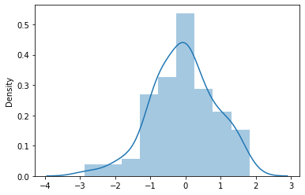

```python
import numpy as np
x = np.random.normal(size=100)
sns.distplot(x)
```

## Plotting bivariate distributions

The easiest way to visualize a bivariate distribution in seaborn is to use the jointplot() function, which creates a multi-panel figure that shows both the bivariate (or joint) relationship between two variables along with the univariate (or marginal) distribution of each on separate axes.

```python
mean, cov = [0, 1], [(1, .5), (.5, 1)]
data = np.random.multivariate_normal(mean, cov, 200)
df = pd.DataFrame(data, columns=["x", "y"])
```

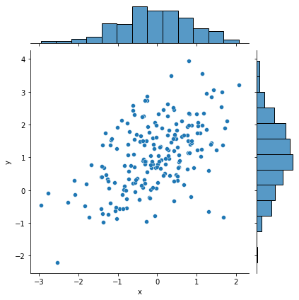

```python
sns.jointplot(x="x", y="y", data=df)
```

**Hexbin plots.** The bivariate analogue of a histogram is known as a “hexbin” plot, because it shows the counts of observations that fall within hexagonal bins. This plot works best with relatively large datasets. It’s availible through the matplotlib plt.hexbin function and as a style in jointplot()

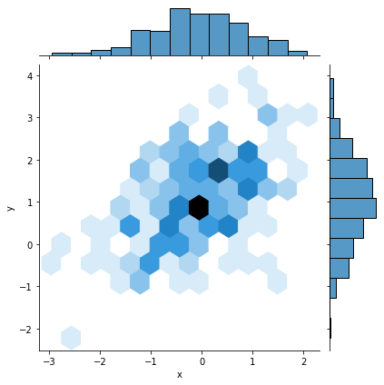

```python
sns.jointplot(x="x", y="y", data=df, kind="hex")
```

**Kernel density estimation.** It is also posible to use the kernel density estimation procedure described above to visualize a bivariate distribution. In seaborn, this kind of plot is shown with a contour plot and is available as a style in jointplot()

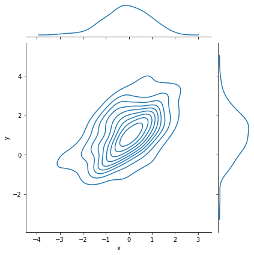

```python
sns.jointplot(x="x", y="y", data=df, kind="kde")
```

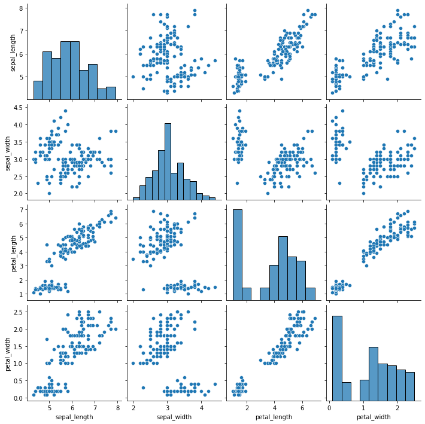

```python
sns.pairplot(flora)
```

```python
# We can add colors to different species
#sns.pairplot(flora, hue="species")
```

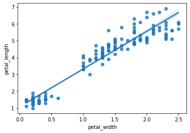

```python
sns.regplot(x="petal_width", y="petal_length", data=flora)
```

**Strip plots.** This is similar to scatter plot but used when one variable is categorical.

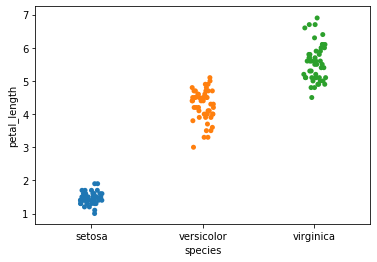

```python
sns.stripplot(x="species", y="petal_length", data=flora)
```

**Box plots**

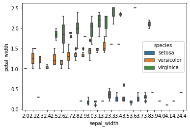

```python
sns.boxplot(x="sepal_width", y="petal_width", hue="species", data=flora)
```

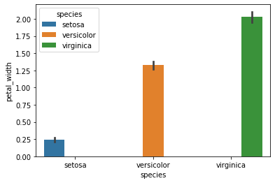

```python
# Kinda lame, need to redo with different data
sns.barplot(x="species", y="petal_width", hue="species", data=flora)
```

## Logistic Regression Plots

```python
df_lobsters = pd.read_csv(r'C:\Users\eric_\Documents\Code\Data\lobster_survive.dat.txt',
                            sep=r'\s+', names=['CarapaceLen', 'Survived'])
display(df_lobsters.head())
print("...")
display(df_lobsters.tail())
```

|  | CarapaceLen | Survived |
| --- | --- | --- |
| 0 | 27 | 0 |
| 1 | 27 | 0 |
| 2 | 27 | 0 |
| 3 | 27 | 0 |
| 4 | 27 | 0 |

```
...
```

|  | CarapaceLen | Survived |
| --- | --- | --- |
| 154 | 54 | 1 |
| 155 | 54 | 1 |
| 156 | 54 | 1 |
| 157 | 54 | 1 |
| 158 | 57 | 1 |

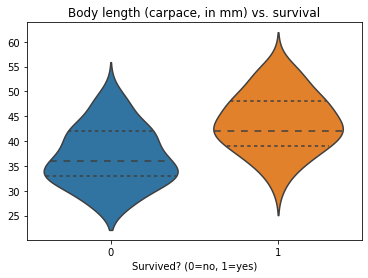

```python
ax = sns.violinplot(x="Survived", y="CarapaceLen",
                    data=df_lobsters, inner="quart")
ax.set(xlabel="Survived? (0=no, 1=yes)",
       ylabel="",
       title="Body length (carpace, in mm) vs. survival");
```

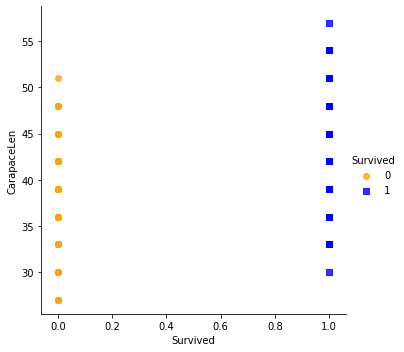

```python
sns.lmplot(x="Survived", y="CarapaceLen", hue="Survived", data=df_lobsters, palette={0: "orange", 1: "blue"},
           markers=['o', 's'], fit_reg=False)
```